# Comparing populations in isotope-space

Andrew L Jackson

14 July 2015

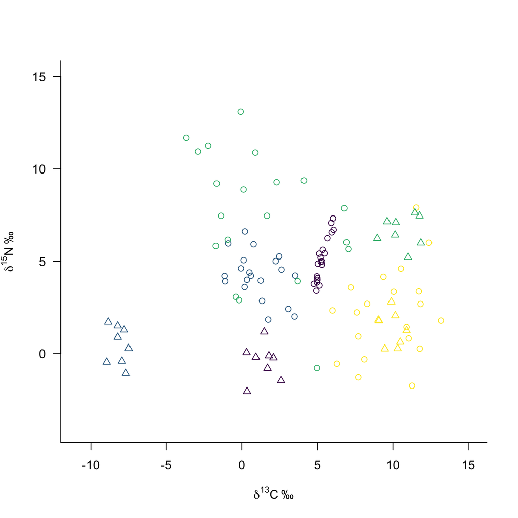

We can visualise this by adding both ellipses, and convex hulls to the data. In this case, we add standard ellipses, which are to bivariate data as standard deviations are to univariate data. A standard ellipse contains approximately 40% of the data, although they can be rescaled to contain any proporition of the data we wish if we accept the assumption that they multivariate normal distributed. Owing to this proportional representation of the data, the ellipse *should* be insensitive to sample size, and *should* always contain 40% of the data. However, as was demonstrated in the SIBER paper [Jackson et al 2010](https://scholar.google.com/citations?view_op=view_citation&hl=en&user=E0sB7fUAAAAJ&citation_for_view=E0sB7fUAAAAJ:_FxGoFyzp5QC), the basic Standard Ellipse Area (SEA) shows bias at small sample sizes, which can be corrected to calculate SEAc.

In contrast, the convex hull is a polygon that is drawn around the outermost points in the cloud of data such that all other points lie within the outline. If we were to go out and collect more samples, then this hull can only grow in size and not get smaller. The result of this is that smaller sample sizes will result in smaller convex hulls. Despite this statistical problem, the convex hull remains a useful way to help us visualise bivariate data such as carbon-nitrogen stable isotope values.

```r
mydata<-read.csv("path/example_layman_data.csv"))
```

And now the full code…

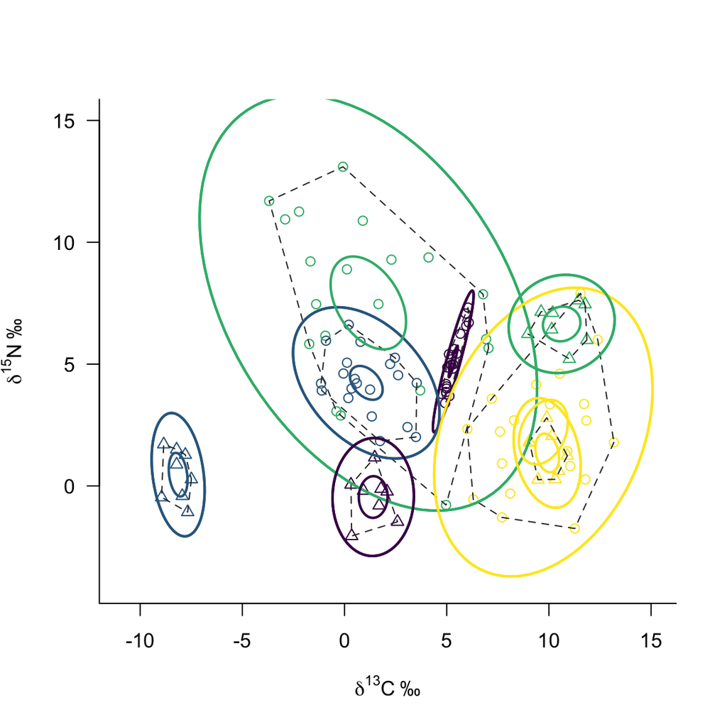

```r
rm(list = ls()) # clear the memory of objects

# load the siar package of functions
library(SIBER)

# read in the data
mydata <- read.csv("../siber-scripts/example_layman_data_all.csv",
                   header=T)

# create the siber object
siber.example <- createSiberObject(mydata)

# Create lists of plotting arguments to be passed onwards to each
# of the three plotting functions.
community.hulls.args <- list(col = 1, lty = 1, lwd = 1)
group.ellipses.args  <- list(n = 100, p.interval = 0.95,
                             lty = 1, lwd = 2)
group.hull.args      <- list(lty = 2, col = "grey20")


# ellipses and group.hulls are set to TRUE or T for short to force
# their plotting.
par(mfrow=c(1,1))
plotSiberObject(siber.example,
                  ax.pad = 2,
                  hulls = F, community.hulls.args,
                  ellipses = T, group.ellipses.args,
                  group.hulls = T, group.hull.args,
                  bty = "L",
                  iso.order = c(1,2),
                  xlab = expression({delta}^13*C~'\u2030'),
                  ylab = expression({delta}^15*N~'\u2030')
                  )

# You can add more ellipses by directly calling plot.group.ellipses()
# Add an additional p.interval % prediction ellilpse
plotGroupEllipses(siber.example, n = 100, p.interval = 0.95,
                    lty = 1, lwd = 2)

# or you can add the XX% confidence interval around the bivariate means
# by specifying ci.mean = T along with whatever p.interval you want.
plotGroupEllipses(siber.example, n = 100, p.interval = 0.95,
                  ci.mean = T, lty = 1, lwd = 2)
```

```r
# Calculate sumamry statistics for each group: TA, SEA and SEAc
group.ML <- groupMetricsML(siber.example)
print(group.ML)
```

```
##            1.1      1.2      1.3      1.4      2.1      2.2      2.3
## TA   1.5555360 14.86029 84.20837 43.81102 4.552414 2.952808 4.434037
## SEA  0.5412062  5.35464 33.73813 15.87191 2.526144 1.666699 2.733655
## SEAc 0.5712732  5.65212 35.61247 16.75368 2.947168 1.944482 3.189264
##           2.4
## TA   2.889293
## SEA  1.873229
## SEAc 2.185434
```

## Using Bayesian Inference to calculate uncertainty around ellipses

So far these still just point-metrics that describe the width of the isotopic niche. That is, they are single numbers for each group, which means that we can’t compare one group to another in a statisical sense as we lack a measure of the uncertainty around each estimate. This is where we can use Bayesian Inference to quantify the error associated with fitting these ellipses to each group, that arises from both the number of samples we have, and also their distribution.

Essentially, what the MCMC algorithm does is generate a distribution of covariance matrices that to a greater or lesser extent (in terms of likelihood) describe the observed data. It does so, as is the general case in Bayesian Inference, by combing the prior probability with the likelihood of the data for a given covariance matrix.

SIBER uses the jags package to fit the Bayesian model and so we need to specify the parameters of the simulation run, including: run length, burn-in period, number of chains etc…

```r
# options for running jags
parms <- list()
parms$n.iter <- 2 * 10^4   # number of iterations to run the model for
parms$n.burnin <- 1 * 10^3 # discard the first set of values
parms$n.thin <- 10     # thin the posterior by this many
parms$n.chains <- 2        # run this many chains

# define the priors
priors <- list()
priors$R <- 1 * diag(2)
priors$k <- 2
priors$tau.mu <- 1.0E-3

# fit the ellipses which uses an Inverse Wishart prior
# on the covariance matrix Sigma, and a vague normal prior on the
# means. Fitting is via the JAGS method.
ellipses.posterior <- siberMVN(siber.example, parms, priors)
```

```
##    Graph Size: 35
##
##
##    Graph Size: 35
##
##
##    Graph Size: 35
##
##
##    Graph Size: 35
##
##
##    Graph Size: 23
##
##
##    Graph Size: 23
##
##
##    Graph Size: 23
##
##
##    Graph Size: 23
##
```

What we end up with is a range of ellipses that could explain the data, with more of them clustered around the most likely solution. However, one cannot simply take an average across these covariance matrices, as there are strict mathematical properties that must be maintained. The result of this is that it is not possible to plot a mean, median or modal Bayesian Standard Ellipse; instead we must calculate each one of the ellipse’s area, and then present summary statistics of this derived measurement. SIBER contains a function that will automatically loop over all the groups and do this.

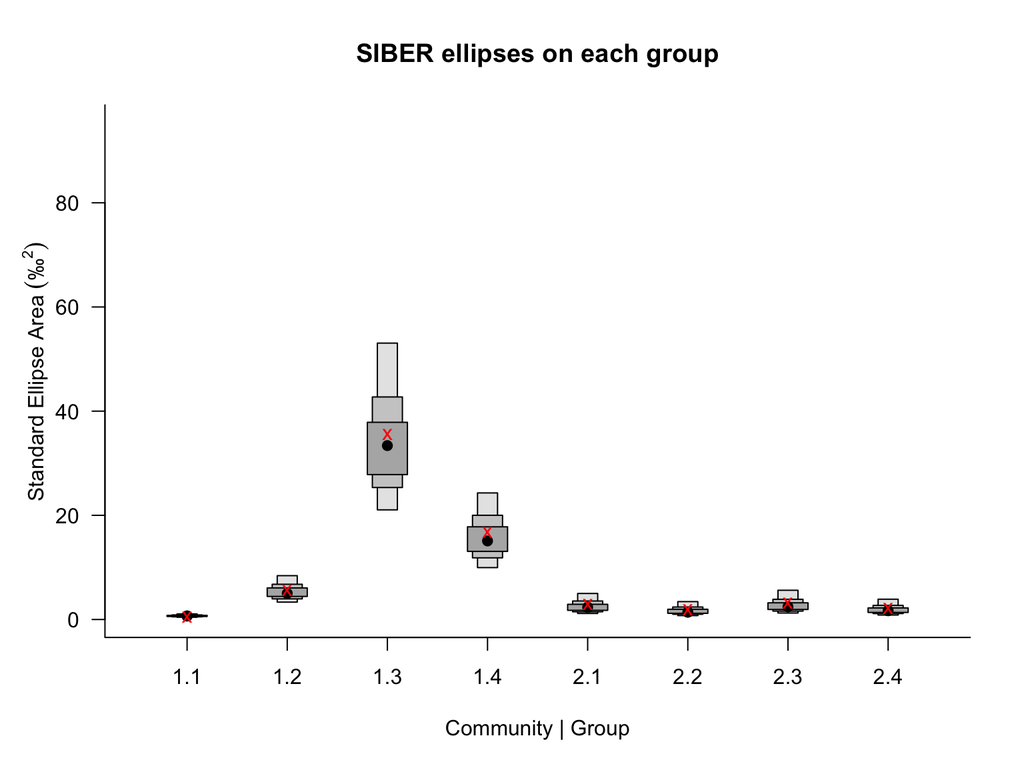

```r
#
# ----------------------------------------------------------------
# Plot out some of the data and results
# ----------------------------------------------------------------

# The posterior estimates of the ellipses for each group can be used to
# calculate the SEA.B for each group.
SEA.B <- siberEllipses(ellipses.posterior)

siberDensityPlot(SEA.B, xticklabels = colnames(group.ML),
                xlab = c("Community | Group"),
                ylab = expression("Standard Ellipse Area " ('\u2030' ^2) ),
                bty = "L",
                las = 1,
                main = "SIBER ellipses on each group"
                )

# Add red x's for the ML estimated SEA-c
points(1:ncol(SEA.B), group.ML[3,], col="red", pch = "x", lwd = 2)
```

```r
# Calculate some credible intervals
cr.p <- c(0.95, 0.99) # vector of quantiles

# call to hdrcde:hdr using lapply()
SEA.B.credibles <- lapply(
  as.data.frame(SEA.B),
  function(x,...){tmp<-hdrcde::hdr(x)$hdr},
  prob = cr.p)

print(SEA.B.credibles)
```

```
## $V1
##          [,1]      [,2]
## 99% 0.3645124 1.2720375
## 95% 0.4297378 1.0729045
## 50% 0.5802088 0.7933467
##
## $V2
##         [,1]     [,2]
## 99% 2.831434 9.665360
## 95% 3.245780 8.333160
## 50% 4.437613 6.076153
##
## $V3
##         [,1]     [,2]
## 99% 15.88144 61.74963
## 95% 19.75147 52.43292
## 50% 28.37719 38.40032
##
## $V4
##          [,1]     [,2]
## 99%  8.212390 28.83149
## 95%  9.817733 24.23096
## 50% 13.136254 17.88706
##
## $V5
##          [,1]     [,2]
## 99% 0.6618904 7.036319
## 95% 1.0607994 4.955483
## 50% 1.7941957 2.954788
##
## $V6
##          [,1]     [,2]     [,3]     [,4]
## 99% 0.4955224 4.590223 4.751045 4.881799
## 95% 0.7145125 3.406659       NA       NA
## 50% 1.1973697 1.978565       NA       NA
##
## $V7
##          [,1]     [,2]
## 99% 0.9013803 7.617177
## 95% 1.2009889 5.586258
## 50% 1.9354722 3.225399
##
## $V8
##          [,1]     [,2]
## 99% 0.6402829 5.004079
## 95% 0.8411173 3.864849
## 50% 1.3557012 2.228317
```

```r
# do similar to get the modes, taking care to pick up multimodal posterior
# distributions if present
SEA.B.modes <- lapply(
  as.data.frame(SEA.B),
  function(x,...){tmp<-hdrcde::hdr(x)$mode},
  prob = cr.p, all.modes=T)

print(SEA.B.modes)
```

```
## $V1
## [1] 0.6762419
##
## $V2
## [1] 5.15888
##
## $V3
## [1] 33.10487
##
## $V4
## [1] 15.17267
##
## $V5
## [1] 2.318317
##
## $V6
## [1] 1.510633
##
## $V7
## [1] 2.488602
##
## $V8
## [1] 1.716999
```

## Comparing the posterior distributions

In order to test whether one group’s ellipse is smaller or larger than another, we can simply calculate the probability that its posterior distribution is smaller (or larger). This is acheived by comparing each pair of posterior draws for both groups, and dtermining which is smaller in magnitude. We then find the proportion of draws that are smaller, and this is a direct proxy for the probability that one group’s posterior distribution (of ellipse size in this case) is smaller than the other.

Here, we first calculate the proportion, and hence probability, of the SEA.B for group 1 being smaller than the SEA.B for group 2.

```r
Pg1.lt.g2 <- sum( SEA.B[,1] < SEA.B[,2] ) / nrow(SEA.B)
print(Pg1.lt.g2)
```

```
## [1] 1
```

So, in this case, all of the estimates for groups 1’s ellipse are smaller than for group 2; although we could probably guess at this given that there appears to be no overlap between then 95% credible intervals of the two groups (see the figure above).

Then we can do exactly the same for groups 1 and 3.

```r
Pg1.lt.g3 <- sum( SEA.B[,1] < SEA.B[,3] ) / nrow(SEA.B)
print(Pg1.lt.g3 )
```

```
## [1] 1
```

And then for the other pairings:

```r
Pg1.lt.g4 <- sum( SEA.B[,1] < SEA.B[,4] ) / nrow(SEA.B)
print(Pg1.lt.g4)
```

```
## [1] 1
```

```r
Pg2.lt.g3 <- sum( SEA.B[,2] < SEA.B[,3] ) / nrow(SEA.B)
print(Pg2.lt.g3)
```

```
## [1] 1
```

```r
Pg3.lt.g4 <- sum( SEA.B[,3] < SEA.B[,4] ) / nrow(SEA.B)
print(Pg3.lt.g4)
```

```
## [1] 0.0085
```

## Overlap Between Ellipses

One can calculate the overlap between two (or more) ellipses. In the first instance, this overlap is simply the area, in units of per mil squared, contained by the shape that lies within the overlapping region. This overlap is most easily calculated by using the SEAc of each ellipse.

The overlap between the SEAc for groups 2 and 3 is given by:

```r
# We have to go back to the original data and split the isotope
# data based on the group identifier. NB, this bit of code wont
# work if you also have multiple communities. For now...
spx <- split(siber.example$original.data$iso1,
             siber.example$original.data$group)
spy <- split(siber.example$original.data$iso2,
             siber.example$original.data$group)

# The overlap function still lives in the siar package so we
# have to load that here to acheive this.
library(siar)
overlap.G2.G3 <- overlap(as.numeric(spx[[2]]), spy[[2]],
                         spx[[3]], spy[[3]],
                         steps = 1)
print(overlap.G2.G3)
```

```
## $overlap
## [1] 0.5319977
##
## $area1
## [1] 20.66056
##
## $area2
## [1] 47.94701
```

One might then wish to calculate the proportion overlap; athough one then runs into a choice as to what the demoninator will be in the equation. You could for instance calculate the proportion of A that overlaps with B, the proporiton of B that overlaps with A, or the proportion of A and B that overlap with each other.

```r
overlap.G2.G3$overlap / overlap.G2.G3$area1
```

```
## [1] 0.02574943
```

```r
overlap.G2.G3$overlap / overlap.G2.G3$area2
```

```
## [1] 0.01109553
```

```r
overlap.G2.G3$overlap / (overlap.G2.G3$area1 + overlap.G2.G3$area2)
```

```
## [1] 0.007754212
```

A problem with this simple overlap calculation is that it yields a point-estimate of overlap based on the maximum likelihood estimated SEA_c. One could in theory calculate the overlap for each ellipse created by the MCMC chain and therefore get a distribution of uncertainty around this measure. However, this requires some code to be written to loop over all the posterior means and covariance matrices and calculate overlap for each one. The overlap code is in a separate package, is relatively slow to run, and will need to be applied to every row in the posterior output. SIBER does not currently have a function to perform this calculation.